# Good data is not the same as Big data, or is it ?

Axel-Cleris Gailloty  
24/11/2020

### Some definition

[figure not shown]

## Large data is not *necessarily* big data

*According to Timandra Harkness*,  
For a data to be qualified as big data it needs to be :

- **D**iverse : it must be made of different sources of information
- **A**utomatic : it must be processed by computers in an automatic way
- **T**ime : it must change with time.
- **A**rtificial Intelligence

To summarize : **Big data refers to the large, diverse sets of information that grow at ever-increasing rates. It encompasses the volume of information, the velocity or speed at which it is created and collected, and the variety or scope of the data points being covered.**

# How is big data created ?

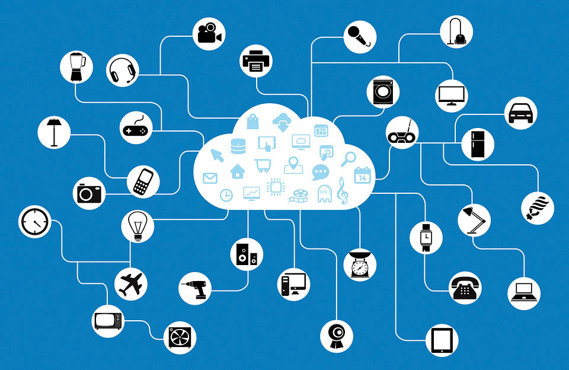

**From 2016, there are double the number of devices online than there are people on the planet. And each of these devices, these tiny sensors, these smart TVs, these connected cars, they are each creating a tiny, continuous vapor trail. And it's the aggregation of these vapor trails into a common place which creates the big in big data.**

# Good data

It was easy to define both data and big data as they refer to realities we can interact with.  
But when it comes to “Good data”, the difficulty in the definition is the adjective good. Certain criteria has to be met before we qualify any data for “good”. The criteria often used to qualify a data set as good data is *“how effectively and efficiently can large data sets be organised, stored and analysed to produce actionable intelligence”*

## Big data is good data : helping face the challenge of cities consumption

## About 70% of the world's population will live in cities by 2050.

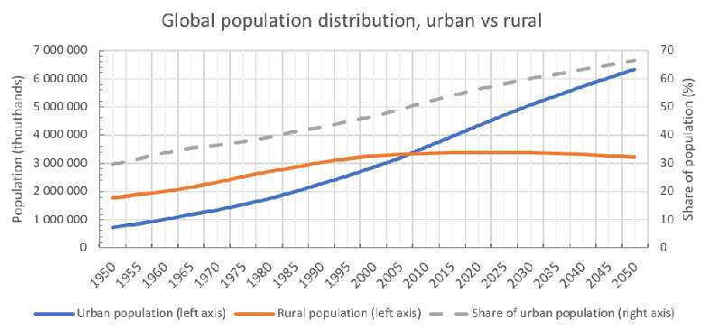

# Big data is good data : helping face the challenge of cities consumption

Cities are the cornerstones of consumption.  
They take up just 3% of the world's land surface area, and yet they are responsible for 75% of global resource consumption. So when we're thinking about sustainability, **that battle will either be won or indeed lost, in our cities**.

## Big data is good data : helping face the challenge of cities consumption

### 90% of the data that exist today did not exit 3 years ago.

We have the rise of the city, and we have the explosion of big data, it's when you bring these two things together, it's at this point of convergence I think things get really interesting.

New York generates a terabyte of data a day. This data is coming from traffic lights, from energy meters, from people's mobile phones, and its the ability to bring together these data streams that allows to better sense the city in real time and decide for how to optimise the consumption.

# Big data for crime prevention

## Only 10% of gun shots are reported

The use of acoustic sensors which are calibrated to detect gun shots have shown that, while people assume that people would report a gun shot heard around 80% of the time it was heard, the reality was actually people only reported it around 10% of the time.

## Big data can help police deploy precious resources in a specific neighborhood.

# Opportunities of big data

If private sector and public sector work together for common good then big data is an asset. Urban information marketplace.

# Urban information marketplace

The urban information marketplace is the bringing together of public and private data into a common platform which digital entrepreneurs can then subscribe to to access data streams, to create innovative apps and services, to make cities more effective.

# Big data can be a threat for privacy

A major threat of big data is about privacy. When the data are collected by private companies then ethic problems will rise.

[figure not shown]

# Is Good data the same as big data ?

## Not necessarily

Small samples of data can be good data when it informs and drives to clear conclusion on an action to perform.

## Big data can be a a weapon for Big Brother

## Kevin Kelly, the founder of WIRED Magazine, said:

*all technology is inherently good,and that it's up to us, as society, to find the appropriate use for it.*

# Thank you

[interactive chart not shown]

[via GIPHY](https://giphy.com/gifs/larrysprings-26FPOogenQv5eOZHO)

# To know more

Big Data Is Good Data | Jen Hawes-Hewitt | TEDxUCL, https://www.youtube.com/watch?v=NP-elwWdPa0

Big data vs Good data : https://www.purchasecontrol.com/blog/is-big-data-good-or-bad/